# — Metadatos Básicos —

date: “Abril 2026”

# — Metadatos Específicos de Plantilla —

# — Bibliografía —

# — Configuración de Salida —

# — Resumen (Abstract) —

La NBA es la mejor liga de baloncesto del mundo, donde los mejores jugadores compiten constantemente bajo presión. En esta Competencia, ganar un partido no solo depende del talento físico, sino también de la inteligencia táctica y del manejo de los datos. El baloncesto moderno de hoy se apoya en la estadística para entender qué factores, como la puntería o el control de los rebotes, aseguran que un equipo permanezca en la cima.

El presente estudio analiza el desempeño de los equipos de la NBA durante la temporada 2021, utilizando una base de datos de 1323 partidos. El objetivo principal es entender por qué algunos equipos ganan y otros pierden, y si esto se debe a una falta de puntería constante o a rachas de inestabilidad durante el juego.

A través de herramientas de estadística y computación, este trabajo explora cómo influyen el porcentaje de tiros, los rebotes y las asistencias en el marcador final. No se trata solo de ver quién anota más, sino de identificar qué factores, como el control del balón y la consistencia en los lanzamientos, son los que realmente aseguran la victoria.

En el baloncesto de élite, ganar un partido no siempre depende de qué tan alto sea el promedio de un equipo, sino de qué tan consistente pueda ser ese rendimiento bajo presión. El análisis de los 1323 registros de la NBA en 2021 revela una interrogante crítica: ¿se pierden los partidos por una falta de talento general o por una irregularidad drástica en momentos clave?

El problema radica en que el porcentaje de tiro (FG_PCT) suele ser volátil. Cuando un equipo pierde, no siempre queda claro si es por una ineficiencia constante o por una alta variabilidad (inestabilidad) en sus lanzamientos. Además, existe una brecha en la comprensión de cómo factores específicos, como superar el 50% de efectividad de campo o dominar la batalla de rebotes, actúan como predictores determinantes de la victoria.

Debido a esto, se plantea las siguientes preguntas de investigación:

¿Es la derrota en la temporada NBA 2021 consecuencia de una ineficiencia constante en el tiro o se debe a una alta volatilidad e inestabilidad en el porcentaje de campo?

¿Como incide la capacidad de domino en el rebote sobre la victoria en el marcador final?

¿Existe una relación en la que los indicadores clave de rendimiento (puntos, rebotes y asistencias) afectan a la estabilidad en el tiro de campo, y si en los juegos más cerrados tienen un menor porcentaje?

El presente trabajo se delimita al análisis de la temporada 2021 con el fin de garantizar la homogeneidad en el contexto táctico y reglamentario de los datos. La selección de este periodo y de las variables correspondientes responde a los siguientes criterios:

Se priorizan aquellos indicadores que reflejan directamente la eficiencia ofensiva y el control del juego, permitiendo un análisis con mayor valor interpretativo. El uso de este subconjunto de datos facilita la aplicación de herramientas de tendencia central, dispersión y tablas bivariantes, objetivos principales de este estudio.

Al centrarse en un año específico, se eliminan ruidos estadísticos provocados por la evolución histórica del juego, permitiendo conclusiones más precisas sobre el rendimiento contemporáneo en la NBA.

El conjunto de datos a utilizar para este estudio pertenece al repositorio abierto de Kaggle (“NBA games data”), del cual se tomo como período de referencia los datos de la NBA temporada 2021.

En este capítulo se definen los conceptos estadísticos y deportivos esenciales para realizar el análisis de los 1323 registros de la temporada de la NBA 2021.

Los conceptos que se presentan a continuación son las herramientas que nos permiten entender qué pasó realmente en la cancha durante la temporada 2021. Para ello, hemos organizado las definiciones en tres partes: las herramientas estadísticas para medir la consistencia, indicadores de juego para evaluar el talento, y el proceso de limpieza de datos, que garantiza que nuestro análisis de los 1323 registros sea lo más cercano posible a la realidad.

Es el valor promedio obtenido al sumar todos los datos de una variable (como el FG_PCT_home) y dividirlo por el número total de registros (n=1323). En este estudio, la media representa la “eficacia esperada” de un equipo en condiciones normales.
$$\bar{x} = \frac{\sum_{i=1}^{n}
x_i}{n}$$

**Correlación:** Cuantifica la fuerza y la dirección de la relación lineal entre dos variables numéricas. Se utiliza para evaluar si existe una dependencia entre variables. Un valor cercano a $+1$ indicaría una relación directa fuerte, mientras que un valor cercano a $0$ indicaría independencia entre las variables analizadas.}
$$r = \frac{\sum_{i=1}^{n} (x_i - \bar{x})(y_i -
\bar{y})}{n\cdot\sqrt{\sum_{i=1}^{n}) (x_i - \bar{x})^2} \cdot
\sqrt{\sum_{i=1}^{n} (y_i - \bar{y})^2}}$$

**Consistencia:** Se define como la capacidad de mantener un rendimiento cercano a la media. Estadísticamente, se mide a través de una baja desviación estándar.

**Volatilidad:** Representa la inestabilidad. Un equipo volátil puede tener partidos de un 60% de efectividad y otros de un 30%, lo que genera incertidumbre en el resultado.

Definida como la variable que proviene de la resta entre puntos anotados y puntos recibidos. Funciona como un indicador de competitividad. Un margen cercano a cero indica un juego de alta presión donde la variabilidad de los datos suele aumentar.

Se refiere al proceso de limpieza y transformación de los datos brutos del archivo NBA.csv.

**Filtrado Lógico:** Se selecciona un subconjunto de datos bajo criterios específicos (Temporada 2021).

**Depuración:** Verificación de valores nulos o atípicos (outliers) que podrían alterar los promedios de la temporada.

Es la estadística general de puntería. Incluye todos los lanzamientos realizados durante el juego (tanto de 2 como de 3 puntos), excluyendo los tiros libres.

**Valor Referencial:** En la NBA, un 45% - 47% se considera el promedio de la liga. Superar el 50% es un indicador de alta eficiencia ofensiva.

Mide la eficacia exclusivamente en lanzamientos detrás de la línea de tres puntos. Es una variable crítica debido a que tiene una mayor volatilidad que los tiros de corta distancia.

**Valor Referencial:** Un 35% - 37% es el estándar de un equipo sólido. Un porcentaje inferior al 30% suele correlacionarse con la derrota en el baloncesto moderno.

Mide la eficiencia en lanzamientos desde la línea de castigo. Aunque no depende de la táctica de juego, es un factor de estabilidad emocional bajo presión.

**Valor Referencial:** El promedio de la liga ronda el 75% - 78%. En finales de partido cerrados, este indicador es determinante para mantener o remontar un marcador.

El rebote **(REB)** representa el momento exacto en el que un equipo recupera la posesión y toma las riendas del juego. En este estudio, lo tratamos como una variable clave de control. La idea es descubrir si existe un umbral de rebotes que asegure estadísticamente la victoria.

Estos parámetros de rendimiento y valores referenciales de eficacia ofensiva han sido extraídos de los estándares estadísticos oficiales de **la National Basketball Association (NBA)** y del repositorio de datos analizado **(“NBA games data”)**.

En esta sección se presentan las metodologías, procedimientos algorítmicos y pruebas estadísticas implementadas para validar los objetivos planteados en este estudio sobre el rendimiento deportivo. Se detalla el tratamiento técnico de la fuente de datos **NBA.csv**, las técnicas de limpieza y transformación de datos y los métodos de análisis descriptivo utilizados para determinar la relación entre la eficiencia en el tiro, el dominio de los rebotes y el resultado final de los encuentros.

La investigación es de tipo descriptiva con enfoque cuantitativo. Se define como un diseño retrospectivo, debido a que se trabaja con eventos deportivos que ya ocurrieron y cuyos datos están almacenados en un soporte digital.

Para este trabajo, la fuente de información es el dataset NBA.csv.

**Población:** Está conformada por todos los registros históricos de partidos de la NBA contenidos en el dataset.

**Muestra:** Los 1323 registros de la temporada 2021 de la NBA. Esta selección garantiza que el análisis sea computacionalmente eficiente y estadísticamente relevante para el contexto actual del baloncesto.

El tratamiento de los datos siguió tres fases fundamentales:

**Limpieza de Datos:** Se verificó la integridad del archivo para asegurar que no existieran valores nulos o vacíos en las métricas críticas.

**Creación de Variables Computadas:** Se generaron nuevas variables para el análisis, tales como el Margen de Victoria y la clasificación de los partidos según su Nivel de Competitividad.

**Medidas de Tendencia Central:** Cálculo de la media para determinar la eficiencia promedio de tiro.

**Medidas de Dispersión:** Aplicación de la Desviación Estándar para cuantificar la volatilidad o inestabilidad del rendimiento entre un partido y otro.

**Coeficiente de Variación:** Empleado como una medida de dispersión relativa para determinar si la variabilidad de los datos es significativa en comparación con su media.

**Correlación:** Utilizada para cuantificar la fuerza y dirección de la relación entre las variables derivadas, permitiendo evaluar la dependencia entre indicadores.

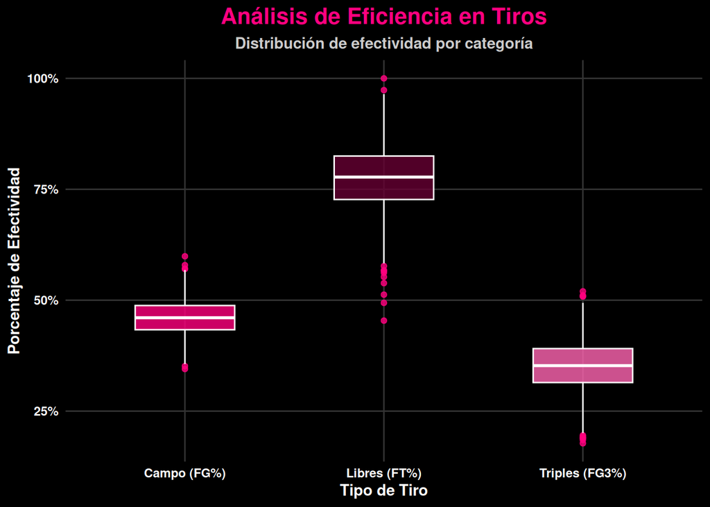

**Interpretación:** Se eligió el Diagrama de Caja y Bigotes porque es la herramienta estándar para medir la dispersión y consistencia. A través de la mediana, el rango intercuartílico y los outliers, el gráfico revela una jerarquía de eficiencia clara:

Los Tiros Libres (FT%) son los más efectivos pero volátiles, mientras que los Tiros de Campo (FG%) muestran una consistencia uniforme entre el 40% y 50% y por el contrario, los Triples (FG3%) se mantienen casi totalmente por debajo de la barrera crítica del 50%, demostrando su mayor dificultad técnica.

La asimetria en los bigotes y la presencia de valores atípicos demuestran que en esta temporada era más probable tener un colapso en tiros libres o una racha extraordinaria en triples que viceversa, confirmando que la eficiencia no sigue una distribución normal sino que depende de la inestabilidad del juego.

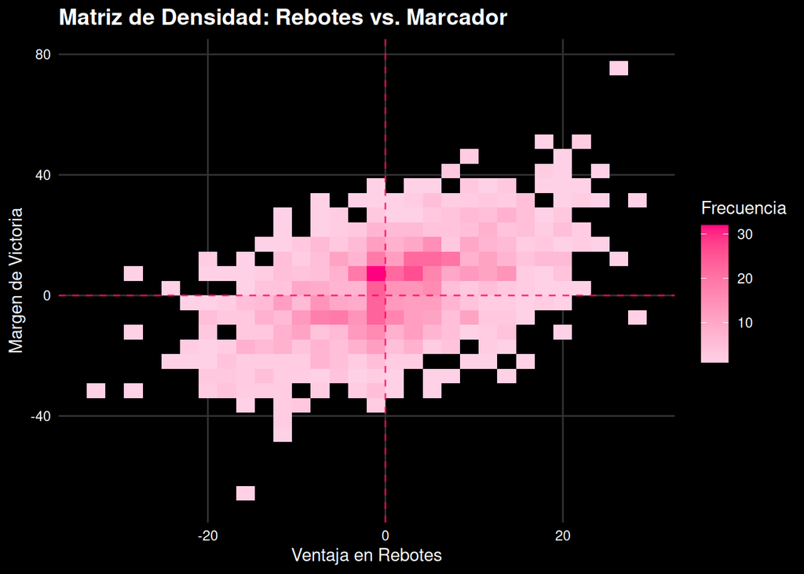

**Interpretación:** Se implementó una Matriz de Densidad (Density Heatmap) por bloques para identificar la moda estadística y mitigar la saturación visual de los miles de registros procesados. Esta estructura de rejilla revela que el “punto caliente” o núcleo de máxima probabilidad se concentra en una ventaja mínima de rebotes (0 a 4) con un margen de victoria estrecho (5 a 9 puntos), demostrando que en la práctica el dominio del tablero suele acompañar a triunfos competitivos y no a victorias holgadas.

Aunque el análisis de cuadrantes confirma que las palizas (más de 15 puntos) rara vez ocurren sin una ventaja física significativa, la densidad de datos cerca del origen valida la paridad competitiva de la liga; el rebote es un factor incremental pero no determinante por sí solo, sugiriendo que la victoria depende de una combinación de eficiencia de tiro y otros factores contextuales. Basicamente, el gráfico demuestra que existe una correlación clara, pero no una causalidad absoluta entre el control del rebote y el resultado final.

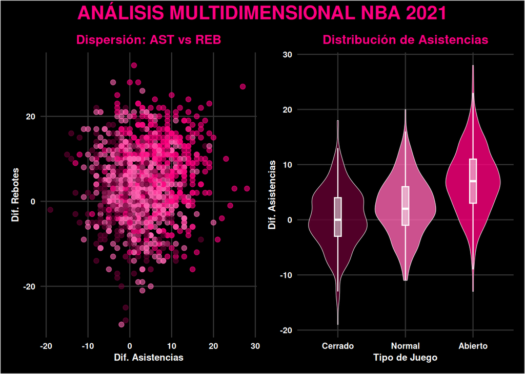

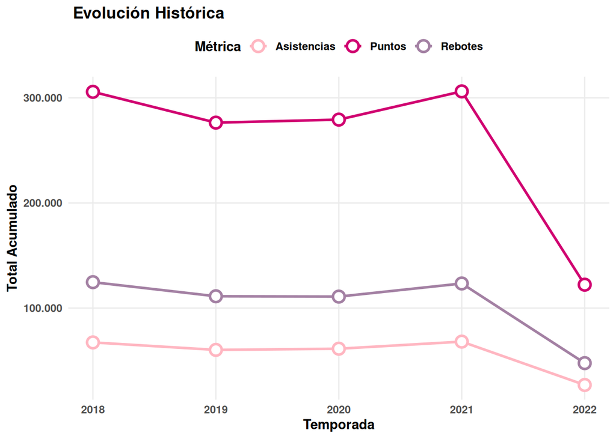

**Interpretación:** Se realizo un grafico de líneas con Marcadores, una herramienta muy útil para el análisis de series temporales, permitiendo identificar la pendiente de las tendencias y comparar magnitudes bajo una escala unificada. Este revela una estabilidad relativa hasta 2020, seguida de una recuperación en 2021 y un descenso pronunciado en 2022. Este último comportamiento se identifica como una variación situacional del dataset, explicada por el corte temporal de la recolección de datos y no necesariamente por un cambio en la dinámica del juego.